# Machine Learning Project

Adrian Stanciu

Saturday, June 20, 2015

## Data retrieving and cleaning

We load the data, and clean the “NA” values. Then, via exploratory data analysis, we remove all the columns that would be incorrect predictors: name, timestamps, window, and aggregates of values (min, max, avg, var, stddev, kurtosis, skewness). This will ensure having a dataset with only numeric measures.

```r
df <- read.csv(file = "pml-training.csv", na.strings=c("NA","","#DIV/0!"))

df$X <- NULL
df$user_name <- NULL
df <- df[, -grep("window", colnames(df))]
df <- df[, -grep("timestamp", colnames(df))]
df <- df[, -grep("kurtosis", colnames(df))]
df <- df[, -grep("skewness", colnames(df))]
df <- df[, -grep("stddev_", colnames(df))]
df <- df[, -grep("avg_", colnames(df))]
df <- df[, -grep("var_", colnames(df))]
df <- df[, -grep("min_", colnames(df))]
df <- df[, -grep("max_", colnames(df))]
df <- df[, -grep("amplitude_", colnames(df))]
```

## Prepare data for cross validation

We split the data for cross-validation into training and testing data. Normally the percentage is 70% / 30%, but in order to avoid very long running times, I only took 30% of the data for training, as it gave accurate enough resuls in a shorter time.

```r
library(caret)
set.seed(3400)

inTrain <- createDataPartition(y=df$classe, p=0.3, list = FALSE)
training <- df[inTrain, ]
testing <- df[-inTrain, ]
```

## Build a model on the training set

First, I tried a linear model, but it did not work properly. Therefore I tried a more complex model, a “Random Forest” model.

```r
# Use random forest
# Add cross-validation
tc <- trainControl(allowParallel = TRUE, method="cv", number=3)
modelFitRandomForest <- train(classe~., data=training, method="rf", trainControl=tc)
fm <- modelFitRandomForest$finalModel
print(fm)
```

```
##
## Call:
##  randomForest(x = x, y = y, mtry = param$mtry, trainControl = ..1)
##                Type of random forest: classification
##                      Number of trees: 500
## No. of variables tried at each split: 27
##
##         OOB estimate of  error rate: 1.87%
## Confusion matrix:
##      A    B    C   D    E class.error
## A 1662    7    4   1    0 0.007168459
## B   27 1103   10   0    0 0.032456140
## C    0   12 1005  10    0 0.021421616
## D    1    1   22 938    3 0.027979275
## E    0    0    5   7 1071 0.011080332
```

The in-sample error is 1.87%.

Check with varImp the accuracy of the predictors. This allowed me via trial and error to remove unwanted columns such as the first column X that were influencing the model.

```r
varImp(fm)
```

```
##                        Overall
## roll_belt            590.47303
## pitch_belt           239.55721
## yaw_belt             312.11028
## total_accel_belt      19.68671
## gyros_belt_x          27.10463
## gyros_belt_y          22.31819
## gyros_belt_z          67.41580
## accel_belt_x          18.09577
## accel_belt_y          19.22918
## accel_belt_z          88.89643
## magnet_belt_x         78.48448
## magnet_belt_y         90.80853
## magnet_belt_z         95.44895
## roll_arm              62.61560
## pitch_arm             35.02511
## yaw_arm               54.26502
## total_accel_arm       21.28802
## gyros_arm_x           26.33873
## gyros_arm_y           36.46269
## gyros_arm_z           13.79805
## accel_arm_x           48.52500
## accel_arm_y           31.58660
## accel_arm_z           24.73800
## magnet_arm_x          39.43834
## magnet_arm_y          42.13580
## magnet_arm_z          39.96144
## roll_dumbbell        107.74587
## pitch_dumbbell        44.69067
## yaw_dumbbell          63.60333
## total_accel_dumbbell  93.08595
## gyros_dumbbell_x      29.47338
## gyros_dumbbell_y      54.38021
## gyros_dumbbell_z      22.73941
## accel_dumbbell_x      50.77370
## accel_dumbbell_y     153.28859
## accel_dumbbell_z      86.36872
## magnet_dumbbell_x    104.18247
## magnet_dumbbell_y    271.37261
## magnet_dumbbell_z    264.13196
## roll_forearm         271.75983
## pitch_forearm        347.44861
## yaw_forearm           41.94205
## total_accel_forearm   23.59124
## gyros_forearm_x       16.18960
## gyros_forearm_y       27.39306
## gyros_forearm_z       19.77065
## accel_forearm_x      117.14598
## accel_forearm_y       32.80034
## accel_forearm_z       61.98576
## magnet_forearm_x      47.72944
## magnet_forearm_y      51.89905
## magnet_forearm_z     103.88559
```

## Plot accuracy

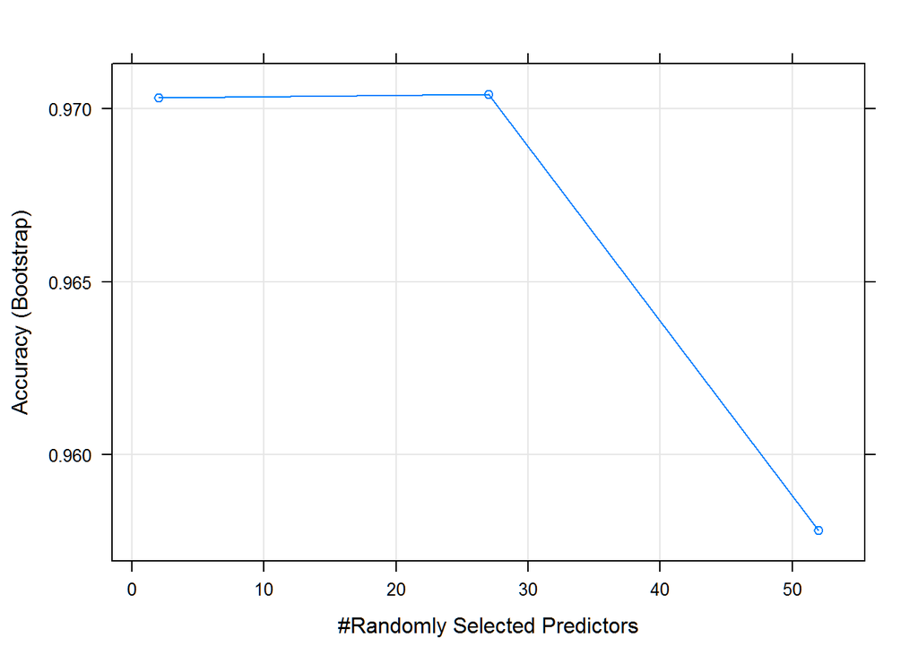

```r
plot(modelFitRandomForest)
```

## Calculate the error with cross-validation

```r
pred <- predict(modelFitRandomForest, newdata = testing)
confusionMatrix(pred, testing$classe)
```

```
## Confusion Matrix and Statistics
##
##           Reference
## Prediction    A    B    C    D    E
##          A 3896   51    0    0    0
##          B    6 2547   28    7    7
##          C    2   57 2339   45    8
##          D    1    1   27 2191   22
##          E    1    1    1    8 2487
##
## Overall Statistics
##
##                Accuracy : 0.9801
##                  95% CI : (0.9776, 0.9824)
##     No Information Rate : 0.2844
##     P-Value [Acc > NIR] : < 2.2e-16
##
##                   Kappa : 0.9748
##  Mcnemar's Test P-Value : 4.98e-12
##
## Statistics by Class:
##
##                      Class: A Class: B Class: C Class: D Class: E
## Sensitivity            0.9974   0.9586   0.9766   0.9733   0.9853
## Specificity            0.9948   0.9957   0.9901   0.9956   0.9990
## Pos Pred Value         0.9871   0.9815   0.9543   0.9773   0.9956
## Neg Pred Value         0.9990   0.9901   0.9950   0.9948   0.9967
## Prevalence             0.2844   0.1935   0.1744   0.1639   0.1838
## Detection Rate         0.2837   0.1855   0.1703   0.1595   0.1811
## Detection Prevalence   0.2874   0.1890   0.1785   0.1633   0.1819
## Balanced Accuracy      0.9961   0.9771   0.9834   0.9845   0.9922
```

The accuracy is 98%. Therefore the expected out-of-sample error is 2%.

## Predict values from the testing data

```r
testSet <- read.csv(file = "pml-testing.csv", na.strings=c("NA","","#DIV/0!"))
answers <-  as.character(predict(modelFitRandomForest, testSet))

# write prediction files
pml_write_files = function(x){
    n = length(x)
    for(i in 1:n){
        filename = paste0("./prediction/problem_id_", i, ".txt")
        write.table(x[i], file = filename, quote = FALSE, row.names = FALSE, col.names = FALSE)
    }
}
pml_write_files(answers)
```